# Week 6 Worksheet

Barry

15/05/2020

# Introduction

For this weeks worksheet I have tried my best to present you with a ‘real’ large omics dataset. We are going to a breast cancer dataset, GSE96058 from the GEO database. The study was conducted by the Population-Based Multicenter Sweden Cancerome Analysis Network—Breast Initiative. I have pre filtered the file to contain only basal and Her2 breast cancer subtypes, per pam50 subtye classification.

# Part 1: Read in Data

1. Read in the gene expression and metadata file. (hint: set row.names = “Gene” for expression file and row.names = “Sample_ID” for the metadata file)

```r
mat <- read.csv("~/Desktop/CRT_ML/files/GSE96058.gene_expr.csv", header=T, row.names = "Gene", sep=",")
meta <- read.csv("~/Desktop/CRT_ML/files/GSE96058.metadata.csv", header=T, row.names = "Sample_ID", sep=",")
```

2. Check the number of subtypes present in the metadata file

```r
table(meta$Subtype)
```

```
##
## Basal  Her2
##   360   348
```

# Part 2: Pre Process Data

1. Check the distribution of expression values for the first 20 samples. Please use a boxplot.

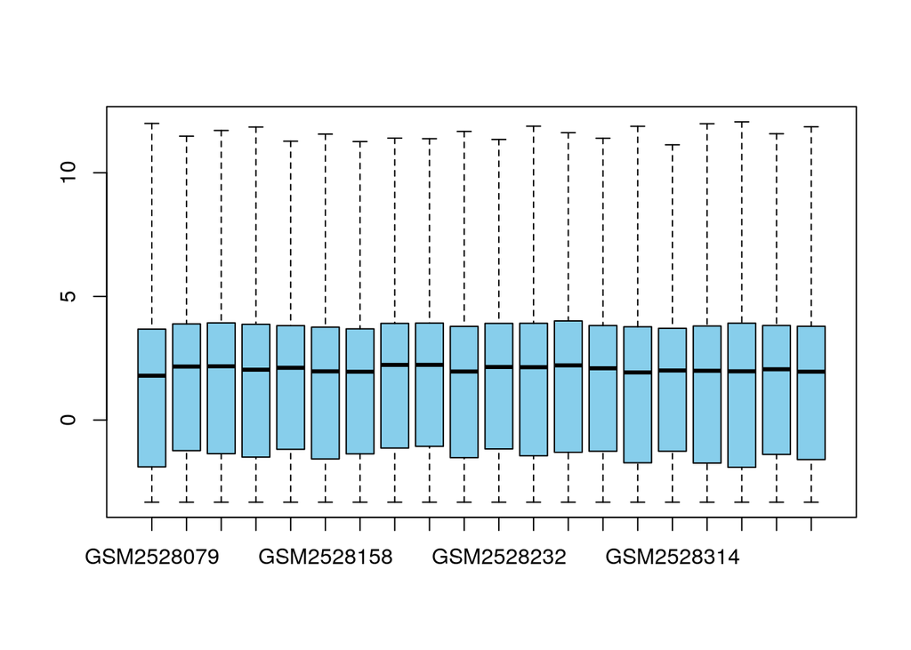

```r
boxplot(mat[,1:20], outline=F, col="skyblue")
```

b) Check the distribution of 4 samples individually by using a histogram. To render 4 plots to one graphics device, call `par(mfrow=c(2,2))` at the beginning of the code block.

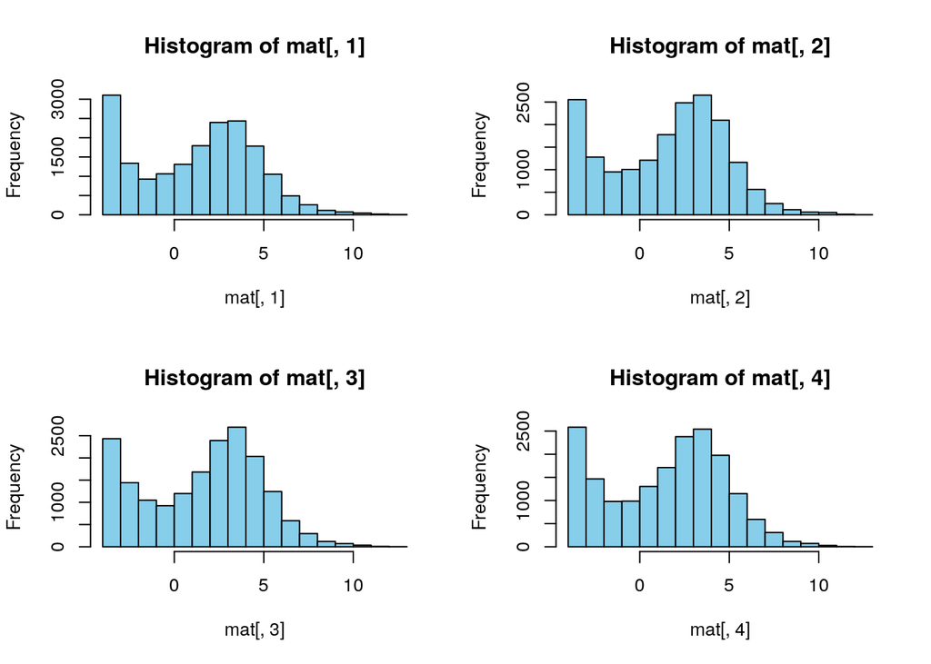

```r
par(mfrow=c(2,2))

hist(mat[,1], col="skyblue")
hist(mat[,2], col="skyblue")
hist(mat[,3], col="skyblue")
hist(mat[,4], col="skyblue")
```

What can we say about the distribution of the gene expression values? Do you think it follows a normal distribution?

Do you think that the data requires any transformations? If so, check the distribution of the histograms by calling `hist(log2(mat[,1] +1))` to see the effect of a log2 transformation. Which one is skewed?

3. Scale and center the dataset by using the base R function. Recall the `scale()` function operates on columns. We want to scale the genes.

```r
mat <- t(mat)
mat <- scale(mat, center = T)
mat <- t(mat)
```

4. Subset the dataset to extract the top 2000 variable genes. Take into consideration that the genes are on the rows of the gene expression matrix. When using the `apply()` function change it to `apply(mat,1,sd)`, which differs from the `apply(mat,2,sd)` call made in the learning materials. Can you see why we did this? Look up the documentation of `apply()` to see why. When subsetting the gene expression matrix, remember to subset by rows not columns.

```r
SDs=apply(mat,1,sd )
topPreds=order(SDs,decreasing = TRUE)[1:2000]
mat=mat[topPreds,]
```